# 重賞レース予測レポート【毎時自動更新中】

作成日時: 2026/09/20 10:04:14

☞ [マニュアル(pdf)](https://ryutoro-galois.github.io/keiba-predictor/manual/manual.pdf)

☞ 過去6年の同一レース結果: [2025年](https://ryutoro-galois.github.io/keiba-predictor/report/PredResult_2025y_raceDate_20250920_20250921.html), [2024年](https://ryutoro-galois.github.io/keiba-predictor/report/PredResult_2024y_raceDate_20240922_20240922.html), [2023年](https://ryutoro-galois.github.io/keiba-predictor/report/PredResult_2023y_raceDate_20230924_20230924.html), [2022年](https://ryutoro-galois.github.io/keiba-predictor/report/PredResult_2022y_raceDate_20220925_20220925.html), [2021年](https://ryutoro-galois.github.io/keiba-predictor/report/PredResult_2021y_raceDate_20210926_20210926.html), [2020年](https://ryutoro-galois.github.io/keiba-predictor/report/PredResult_2020y_raceDate_20200927_20200927.html)

☞ 過去4週間の別レース結果: [1週前(9/12-13)](https://ryutoro-galois.github.io/keiba-predictor/report/PredResult_2026y_raceDate_20260912_20260913.html), [2週前(9/5-6)](https://ryutoro-galois.github.io/keiba-predictor/report/PredResult_2026y_raceDate_20260905_20260906.html), [3週前(8/30)](https://ryutoro-galois.github.io/keiba-predictor/report/PredResult_2026y_raceDate_20260830_20260830.html), [4週前(8/23)](https://ryutoro-galois.github.io/keiba-predictor/report/PredResult_2026y_raceDate_20260823_20260823.html)

☞ netkeiba: [阪神ジャンプステークス(JGⅢ)](https://race.netkeiba.com/race/shutuba.html?race_id=202609040504&rf=race_list), [オールカマー(GⅡ)](https://race.netkeiba.com/race/shutuba.html?race_id=202606040611&rf=race_list), [神戸新聞杯(GⅡ)](https://race.netkeiba.com/race/shutuba.html?race_id=202609040711&rf=race_list)

## 0. 推し馬予測 (AI予測)

### 【阪神ジャンプステークス(J.GⅢ) 2026/09/19(土)】

- 本命(◎): 1-3着内確率(勝負強さ)が1位の馬
- 対抗(◯): 1-3着内確率が2-N位(20%程度以上)の中で予測タイムが最も速い馬
- 3番手(▲): 1-3着内確率が2-N位(20%程度以上)のでダークホース確率が最も高い馬
- 穴: ダークホース確率が上位1-M位(40%程度以上)の中で1-3着内確率が最も高い馬

| 推し馬 | 枠番 | 馬番 | 人気 | オッズ | 馬名 | 騎手 | 調教師 | 予測タイム(sec) | 1_順位 | 1-3着内確率(%) | 2_順位 | ﾀﾞｰｸﾎｰｽ確率(%) | 3_順位 |
| --- | --- | --- | --- | --- | --- | --- | --- | --- | --- | --- | --- | --- | --- |
| 本命(◎) | 2 | 2 | 2 | 3.0 | ジューンベロシティ | 高田潤 | 武英智 | 217.2 | 6 | 23.1 | 1 | 0.4 | 12 |
| 対抗(◯) | 5 | 5 | 1 | 1.7 | ホウオウプロサンゲ | 小野寺祐太 | 矢作芳人 | 204.8 | 1 | 15.9 | 2 | 0.8 | 11 |
| 3番手(▲) | 8 | 11 | 11 | 114.7 | トーアモルペウス | 大江原圭 | 辻哲英 | 213.8 | 2 | 10.8 | 4 | 63.5 | 1 |
| 穴 | 4 | 4 | 7 | 53.1 | アトラクティーボ | 坂口智康 | 武藤善則 | 217.3 | 7 | 2.6 | 8 | 14.4 | 4 |

### 【オールカマー(GⅡ) 2026/09/20(日)】

- 本命(◎): 1-3着内確率(勝負強さ)が1位の馬
- 対抗(◯): 1-3着内確率が2-N位(20%程度以上)の中で予測タイムが最も速い馬
- 3番手(▲): 1-3着内確率が2-N位(20%程度以上)のでダークホース確率が最も高い馬
- 穴: ダークホース確率が上位1-M位(40%程度以上)の中で1-3着内確率が最も高い馬

| 推し馬 | 枠番 | 馬番 | 人気 | オッズ | 馬名 | 騎手 | 調教師 | 予測タイム(sec) | 1_順位 | 1-3着内確率(%) | 2_順位 | ﾀﾞｰｸﾎｰｽ確率(%) | 3_順位 |
| --- | --- | --- | --- | --- | --- | --- | --- | --- | --- | --- | --- | --- | --- |
| 本命(◎) | 5 | 7 | 1 | 3.0 | レガレイラ | 戸崎圭太 | 木村哲也 | 131.2 | 1 | 29.1 | 1 | 0.5 | 12 |
| 対抗(◯) | 6 | 9 | 2 | 4.0 | コスモキュランダ | 横山武史 | 加藤士津八 | 138.0 | 2 | 21.2 | 2 | 0.4 | 13 |
| 3番手(▲) | 8 | 12 | 4 | 9.5 | エセルフリーダ | 武藤雅 | 武藤善則 | 140.8 | 10 | 10.6 | 5 | 2.3 | 7 |
| 穴 | 3 | 3 | 9 | 28.6 | リビアングラス | 西村淳也 | 矢作芳人 | 140.1 | 8 | 4.5 | 8 | 44.9 | 2 |

### 【神戸新聞杯(GⅡ) 2026/09/21(月)】

- 本命(◎): 1-3着内確率(勝負強さ)が1位の馬
- 対抗(◯): 1-3着内確率が2-N位(20%程度以上)の中で予測タイムが最も速い馬
- 3番手(▲): 1-3着内確率が2-N位(20%程度以上)のでダークホース確率が最も高い馬
- 穴: ダークホース確率が上位1-M位(40%程度以上)の中で1-3着内確率が最も高い馬

| 推し馬 | 枠番 | 馬番 | 人気 | オッズ | 馬名 | 騎手 | 調教師 | 予測タイム(sec) | 1_順位 | 1-3着内確率(%) | 2_順位 | ﾀﾞｰｸﾎｰｽ確率(%) | 3_順位 |
| --- | --- | --- | --- | --- | --- | --- | --- | --- | --- | --- | --- | --- | --- |
| 本命(◎) | 1 | 1 | 1 | 1.2 | ロブチェン | 松山弘平 | 杉山晴紀 | 144.4 | 1 | 22.5 | 1 | 0.8 | 11 |
| 対抗(◯) | 4 | 4 | 6 | 19.9 | アルトラムス | 岩田望来 | 野中賢二 | 155.2 | 6 | 20.3 | 2 | 1.6 | 10 |
| 3番手(▲) | 6 | 6 | 7 | 28.7 | エムズビギン | 武豊 | 友道康夫 | 155.1 | 5 | 18.3 | 3 | 53.9 | 2 |
| 穴 | 8 | 11 | 8 | 42.9 | ショウナンハヤナミ | 池添謙一 | 渡辺薫彦 | 153.6 | 2 | 11.8 | 7 | 40.2 | 4 |

## 1. 予測チャート (タイム/勝負強さ)

### 【阪神ジャンプステークス(J.GⅢ)】

2026/09/19(土), 09_阪神, 障芝3140m

[interactive chart not shown]

### 【オールカマー(GⅡ)】

2026/09/20(日), 06_中山, 芝右外2200m

[interactive chart not shown]

### 【神戸新聞杯(GⅡ)】

2026/09/21(月), 09_阪神, 芝右外2400m

[interactive chart not shown]

## 2. オッズモニタリング (毎時)

### 【阪神ジャンプステークス】

[interactive chart not shown]

### 【オールカマー】

[interactive chart not shown]

### 【神戸新聞杯】

[interactive chart not shown]

## 3. 出馬表

### 【阪神ジャンプステークス 2026/09/19(土) 】

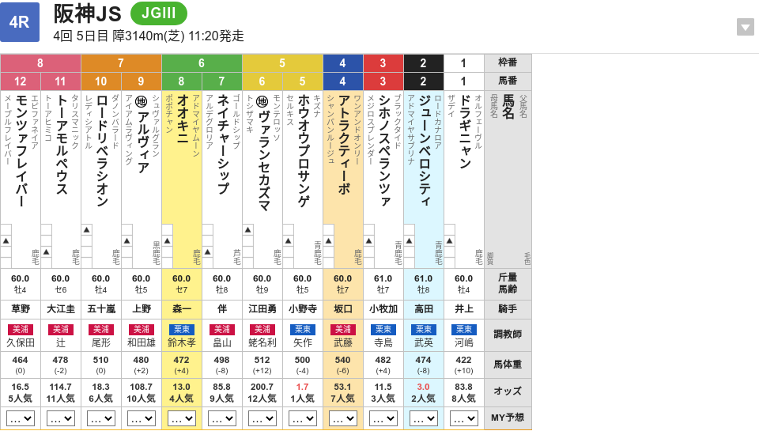

### 【オールカマー 2026/09/20(日) 】

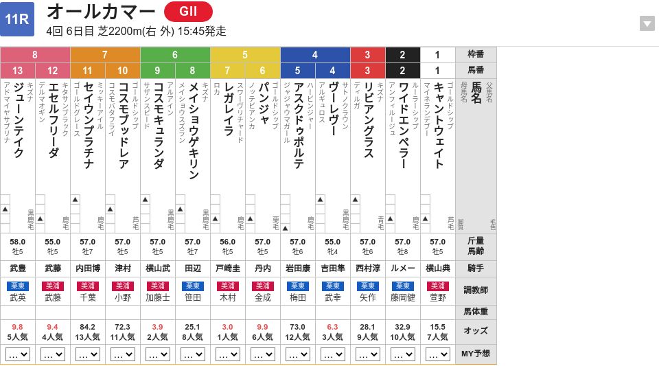

### 【神戸新聞杯 2026/09/21(月) 】

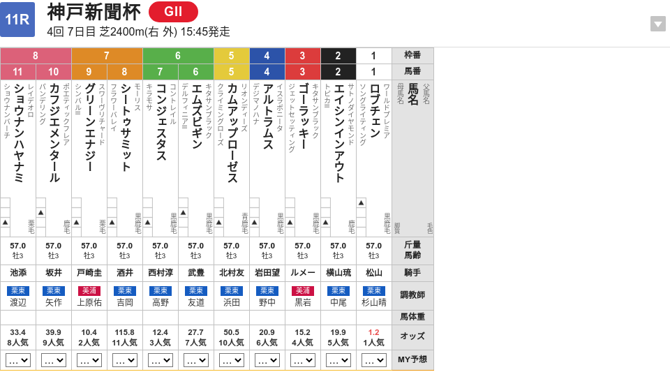

## 4. 単勝予測結果

### 【阪神ジャンプステークス(J.GⅢ) 2026/09/19(土)】

| 枠番 | 馬番 | 人気 | オッズ | 馬名 | 騎手 | 調教師 | 予測タイム(sec) | 1_順位 | 1-3着内確率(%) | 2_順位 | ﾀﾞｰｸﾎｰｽ確率(%) | 3_順位 |
| --- | --- | --- | --- | --- | --- | --- | --- | --- | --- | --- | --- | --- |
| 1 | 1 | 8 | 83.8 | ドラギニャン | 井上敏樹 | 河嶋宏樹 | 221.0 | 10.5 | 2.4 | 9 | 10.8 | 6 |
| 2 | 2 | 2 | 3.0 | ジューンベロシティ | 高田潤 | 武英智 | 217.2 | 6.0 | 23.1 | 1 | 0.4 | 12 |
| 3 | 3 | 3 | 11.5 | シホノスペランツァ | 小牧加矢太 | 寺島良 | 216.3 | 4.0 | 13.2 | 3 | 1.0 | 9 |
| 4 | 4 | 7 | 53.1 | アトラクティーボ | 坂口智康 | 武藤善則 | 217.3 | 7.0 | 2.6 | 8 | 14.4 | 4 |
| 5 | 5 | 1 | 1.7 | ホウオウプロサンゲ | 小野寺祐太 | 矢作芳人 | 204.8 | 1.0 | 15.9 | 2 | 0.8 | 11 |
| 5 | 6 | 12 | 200.7 | ヴァランセカズマ | 江田勇亮 | 蛯名利弘 | 214.8 | 3.0 | 1.9 | 10 | 19.5 | 3 |
| 6 | 7 | 9 | 85.8 | ネイチャーシップ | 伴啓太 | 畠山吉宏 | 220.8 | 9.0 | 1.5 | 12 | 12.4 | 5 |
| 6 | 8 | 4 | 13.0 | オオキニ | 森一馬 | 鈴木孝志 | 221.1 | 12.0 | 9.5 | 5 | 1.1 | 8 |
| 7 | 9 | 10 | 108.7 | アルヴィア | 上野翔 | 和田雄二 | 219.9 | 8.0 | 1.8 | 11 | 22.6 | 2 |
| 7 | 10 | 6 | 18.3 | ロードリベラシオン | 五十嵐雄祐 | 尾形和幸 | 216.8 | 5.0 | 5.7 | 7 | 1.0 | 10 |

[output cut: 2 more lines]

### 【オールカマー(GⅡ) 2026/09/20(日)】

| 枠番 | 馬番 | 人気 | オッズ | 馬名 | 騎手 | 調教師 | 予測タイム(sec) | 1_順位 | 1-3着内確率(%) | 2_順位 | ﾀﾞｰｸﾎｰｽ確率(%) | 3_順位 |
| --- | --- | --- | --- | --- | --- | --- | --- | --- | --- | --- | --- | --- |
| 1 | 1 | 7 | 15.8 | キャントウェイト | 横山典弘 | 萱野浩二 | 140.0 | 7 | 7.9 | 7 | 1.7 | 8 |
| 2 | 2 | 10 | 33.3 | ワイドエンペラー | Ｃ．ルメール | 藤岡健一 | 141.5 | 13 | 2.9 | 9 | 8.9 | 6 |
| 3 | 3 | 9 | 28.6 | リビアングラス | 西村淳也 | 矢作芳人 | 140.1 | 8 | 4.5 | 8 | 44.9 | 2 |
| 4 | 4 | 3 | 6.4 | ヴーレヴー | 吉田隼人 | 武幸四郎 | 139.7 | 4 | 19.6 | 3 | 1.1 | 10 |
| 4 | 5 | 11 | 72.1 | アスクドゥポルテ | 岩田康誠 | 梅田智之 | 138.1 | 3 | 2.2 | 12 | 23.8 | 4 |
| 5 | 6 | 5 | 9.9 | パンジャ | 丹内祐次 | 金成貴史 | 141.3 | 12 | 9.4 | 6 | 1.0 | 11 |
| 5 | 7 | 1 | 3.0 | レガレイラ | 戸崎圭太 | 木村哲也 | 131.2 | 1 | 29.1 | 1 | 0.5 | 12 |
| 6 | 8 | 8 | 25.5 | メイショウゲキリン | 田辺裕信 | 笹田和秀 | 139.9 | 5 | 2.6 | 10 | 27.9 | 3 |
| 6 | 9 | 2 | 4.0 | コスモキュランダ | 横山武史 | 加藤士津八 | 138.0 | 2 | 21.2 | 2 | 0.4 | 13 |
| 7 | 10 | 12 | 75.6 | コスモブッドレア | 津村明秀 | 小野次郎 | 141.0 | 11 | 2.2 | 11 | 70.7 | 1 |

[output cut: 3 more lines]

### 【神戸新聞杯(GⅡ) 2026/09/21(月)】

| 枠番 | 馬番 | 人気 | オッズ | 馬名 | 騎手 | 調教師 | 予測タイム(sec) | 1_順位 | 1-3着内確率(%) | 2_順位 | ﾀﾞｰｸﾎｰｽ確率(%) | 3_順位 |
| --- | --- | --- | --- | --- | --- | --- | --- | --- | --- | --- | --- | --- |
| 1 | 1 | 1 | 1.2 | ロブチェン | 松山弘平 | 杉山晴紀 | 144.4 | 1 | 22.5 | 1 | 0.8 | 11 |
| 2 | 2 | 5 | 18.7 | エイシンインアウト | 横山琉人 | 中尾秀正 | 156.3 | 11 | 7.7 | 9 | 2.1 | 6 |
| 3 | 3 | 4 | 15.1 | ゴーラッキー | Ｃ．ルメール | 黒岩陽一 | 155.2 | 7 | 14.2 | 5 | 1.7 | 9 |
| 4 | 4 | 6 | 19.9 | アルトラムス | 岩田望来 | 野中賢二 | 155.2 | 6 | 20.3 | 2 | 1.6 | 10 |
| 5 | 5 | 9 | 45.6 | カムアップローゼス | 北村友一 | 浜田多実雄 | 155.9 | 9 | 3.2 | 10 | 51.6 | 3 |
| 6 | 6 | 7 | 28.7 | エムズビギン | 武豊 | 友道康夫 | 155.1 | 5 | 18.3 | 3 | 53.9 | 2 |
| 6 | 7 | 3 | 11.4 | コンジェスタス | 西村淳也 | 高野友和 | 155.6 | 8 | 14.2 | 4 | 2.0 | 7 |
| 7 | 8 | 11 | 116.1 | シートゥサミット | 酒井学 | 吉岡辰弥 | 156.3 | 10 | 2.8 | 11 | 22.5 | 5 |
| 7 | 9 | 2 | 9.9 | グリーンエナジー | 戸崎圭太 | 上原佑紀 | 155.0 | 4 | 12.2 | 6 | 1.8 | 8 |
| 8 | 10 | 10 | 45.9 | カフジエメンタール | 坂井瑠星 | 矢作芳人 | 154.9 | 3 | 11.2 | 8 | 66.4 | 1 |

[output cut: 1 more lines]

## 5. 人気と着順の乖離率推移

### 【阪神ジャンプステークス_2001y_2019y】

[interactive chart not shown]

### 【オールカマー_1990y_2019y】

[interactive chart not shown]

### 【神戸新聞杯_1990y_2019y】

[interactive chart not shown]

### 【阪神ジャンプステークス_2001y_2019y】

| No | 開催年 | 不整合率(%) | 頭数 | 人気別着順(1-3位) | 人気別着順(全体) |
| --- | --- | --- | --- | --- | --- |
| 19 | 2019 | 27.6 | 11頭 | 4-1-6 | 4\|1\|6\|2\|7\|11\|12\|3\|5\|8\|9 |
| 18 | 2018 | 35.1 | 9頭 | 1-4-6 | 1\|4\|6\|3\|2\|7\|5\|9\|8 |
| 17 | 2017 | 33.6 | 6頭 | 1-4-6 | 1\|4\|6\|5\|2\|7 |
| 16 | 2016 | 8.2 | 11頭 | 1-2-10 | 1\|2\|10\|3\|5\|4\|8\|7\|9\|6\|11 |
| 15 | 2015 | 18.5 | 8頭 | 1-2-9 | 1\|2\|9\|6\|4\|7\|8\|3 |
| 14 | 2014 | 11.1 | 11頭 | 1-6-2 | 1\|6\|2\|3\|5\|4\|8\|9\|10\|12\|11 |
| 13 | 2013 | 25.4 | 13頭 | 2-1-3 | 2\|1\|3\|9\|6\|10\|5\|8\|4\|12\|11\|14\|13 |
| 12 | 2012 | 48.8 | 11頭 | 4-7-1 | 4\|7\|1\|5\|8\|6\|12\|11\|10\|9\|3 |
| 11 | 2011 | 34.5 | 14頭 | 6-1-5 | 6\|1\|5\|8\|4\|2\|12\|3\|10\|7\|13\|14\|11\|9 |
| 10 | 2010 | 36.1 | 14頭 | 1-8-9 | 1\|8\|9\|3\|5\|4\|11\|12\|13\|7\|2\|6\|14\|10 |

[output cut: 9 more lines]

### 【オールカマー_1990y_2019y】

| No | 開催年 | 不整合率(%) | 頭数 | 人気別着順(1-3位) | 人気別着順(全体) |
| --- | --- | --- | --- | --- | --- |
| 30 | 2019 | 58.1 | 10頭 | 4-3-6 | 4\|3\|6\|1\|5\|7\|8\|10\|2\|9 |
| 29 | 2018 | 21.9 | 12頭 | 1-3-2 | 1\|3\|2\|5\|9\|7\|4\|11\|12\|8\|6\|10 |
| 28 | 2017 | 36.6 | 17頭 | 5-1-3 | 5\|1\|3\|10\|13\|14\|4\|8\|2\|7\|15\|9\|6\|12\|11\|17\|16 |
| 27 | 2016 | 26.4 | 12頭 | 1-3-6 | 1\|3\|6\|4\|2\|8\|5\|11\|7\|9\|12\|10 |
| 26 | 2015 | 34.3 | 15頭 | 3-1-7 | 3\|1\|7\|2\|4\|14\|10\|13\|9\|8\|5\|11\|15\|6\|12 |
| 25 | 2014 | 58.4 | 18頭 | 2-7-12 | 2\|7\|12\|14\|6\|4\|5\|16\|10\|11\|9\|13\|18\|3\|17\|1\|15\|8 |
| 24 | 2013 | 36.9 | 16頭 | 9-2-1 | 9\|2\|1\|5\|7\|8\|6\|4\|3\|10\|13\|12\|16\|15\|14\|11 |
| 23 | 2012 | 36.7 | 15頭 | 2-4-6 | 2\|4\|6\|1\|9\|10\|13\|11\|3\|15\|8\|12\|14\|7\|5 |
| 22 | 2011 | 18.3 | 9頭 | 1-6-2 | 1\|6\|2\|7\|4\|3\|8\|9\|5 |
| 21 | 2010 | 23.9 | 10頭 | 5-1-6 | 5\|1\|6\|7\|2\|3\|10\|9\|4\|8 |

[output cut: 20 more lines]

### 【神戸新聞杯_1990y_2019y】

| No | 開催年 | 不整合率(%) | 頭数 | 人気別着順(1-3位) | 人気別着順(全体) |
| --- | --- | --- | --- | --- | --- |
| 30 | 2019 | 1.8 | 8頭 | 1-2-3 | 1\|2\|3\|4\|6\|5\|7\|8 |
| 29 | 2018 | 36.0 | 10頭 | 2-3-6 | 2\|3\|6\|1\|4\|8\|9\|5\|7\|10 |
| 28 | 2017 | 4.5 | 14頭 | 1-2-3 | 1\|2\|3\|4\|8\|5\|7\|13\|6\|9\|12\|10\|11\|14 |
| 27 | 2016 | 25.7 | 15頭 | 1-6-4 | 1\|6\|4\|5\|2\|3\|10\|7\|9\|8\|13\|11\|14\|12\|15 |
| 26 | 2015 | 46.0 | 15頭 | 3-1-7 | 3\|1\|7\|8\|14\|9\|4\|13\|10\|11\|6\|12\|2\|5\|15 |
| 25 | 2014 | 22.5 | 16頭 | 1-8-9 | 1\|8\|9\|2\|6\|5\|3\|7\|16\|14\|11\|10\|4\|12\|13\|15 |
| 24 | 2013 | 21.3 | 18頭 | 1-7-2 | 1\|7\|2\|8\|6\|16\|3\|5\|13\|9\|11\|12\|14\|15\|17\|10\|4\|18 |
| 23 | 2012 | 17.2 | 15頭 | 1-8-2 | 1\|8\|2\|9\|10\|14\|3\|6\|5\|4\|7\|11\|12\|15\|13 |
| 22 | 2011 | 5.5 | 11頭 | 1-2-3 | 1\|2\|3\|5\|4\|7\|8\|6\|10\|9\|11 |
| 21 | 2010 | 28.4 | 12頭 | 2-1-5 | 2\|1\|5\|10\|3\|8\|11\|7\|6\|4\|12\|9 |

[output cut: 20 more lines]

## 6. 1-3番人気馬の着順分類予測

### 【阪神ジャンプステークス】

| 分類 | 凡例 | 発生確率(%) | 当該レース | 当該レースランク | 直近1年間 |
| --- | --- | --- | --- | --- | --- |
| 1: 1番人気のみ (1_pop1) | 1 \| * \| * | 19.6 | 0.38 | 0.42 | 0.59 |
| 4: 1,2番人気のみ (4_pop12) | 1 \| 2 \| * | 18.0 | 0.90 | 0.90 | 0.00 |
| 8: 1,2,3番人気すべて着外 (8_darkhorse) | * \| * \| * | 14.1 | 0.88 | 0.70 | 0.00 |
| 5: 1,3番人気のみ (5_pop13) | 1 \| 3 \| * | 13.3 | 3.33 | 1.99 | 0.00 |
| 6: 2,3番人気のみ (6_pop23) | 2 \| 3 \| * | 10.0 | 0.00 | 0.00 | 0.00 |
| 2: 2番人気のみ (2_pop2) | 2 \| * \| * | 9.4 | 0.00 | 0.00 | 0.00 |
| 3: 3番人気のみ (3_pop3) | 3 \| * \| * | 8.5 | 0.00 | 0.00 | 0.26 |
| 7: 1,2,3番人気すべて着内 (7_pop123) | 1 \| 2 \| 3 | 7.1 | 0.89 | 1.06 | 0.21 |

### 【オールカマー】

| 分類 | 凡例 | 発生確率(%) | 当該レース | 当該レースランク | 直近1年間 |
| --- | --- | --- | --- | --- | --- |
| 1: 1番人気のみ (1_pop1) | 1 \| * \| * | 19.6 | 1.17 | 1.46 | 0.00 |
| 4: 1,2番人気のみ (4_pop12) | 1 \| 2 \| * | 18.0 | 1.29 | 1.10 | 0.00 |
| 8: 1,2,3番人気すべて着外 (8_darkhorse) | * \| * \| * | 14.1 | 1.70 | 1.88 | 0.00 |
| 5: 1,3番人気のみ (5_pop13) | 1 \| 3 \| * | 13.3 | 0.96 | 1.48 | 0.00 |
| 6: 2,3番人気のみ (6_pop23) | 2 \| 3 \| * | 10.0 | 1.79 | 1.11 | 0.00 |
| 2: 2番人気のみ (2_pop2) | 2 \| * \| * | 9.4 | 0.68 | 1.25 | 0.00 |
| 3: 3番人気のみ (3_pop3) | 3 \| * \| * | 8.5 | 0.44 | 0.71 | 0.17 |
| 7: 1,2,3番人気すべて着内 (7_pop123) | 1 \| 2 \| 3 | 7.1 | 0.86 | 0.28 | 0.14 |

### 【神戸新聞杯】

| 分類 | 凡例 | 発生確率(%) | 当該レース | 当該レースランク | 直近1年間 |
| --- | --- | --- | --- | --- | --- |
| 4: 1,2番人気のみ (4_pop12) | 1 \| 2 \| * | 17.6 | 0.91 | 1.07 | 0.00 |
| 1: 1番人気のみ (1_pop1) | 1 \| * \| * | 17.5 | 1.58 | 1.31 | 0.00 |
| 3: 3番人気のみ (3_pop3) | 3 \| * \| * | 13.5 | 4.82 | 1.13 | 0.27 |
| 5: 1,3番人気のみ (5_pop13) | 1 \| 3 \| * | 13.4 | 2.39 | 1.49 | 0.00 |
| 8: 1,2,3番人気すべて着外 (8_darkhorse) | * \| * \| * | 13.0 | 1.17 | 1.73 | 0.00 |
| 2: 2番人気のみ (2_pop2) | 2 \| * \| * | 9.3 | 0.00 | 1.24 | 0.00 |
| 6: 2,3番人気のみ (6_pop23) | 2 \| 3 \| * | 8.5 | 0.77 | 0.94 | 0.00 |
| 7: 1,2,3番人気すべて着内 (7_pop123) | 1 \| 2 \| 3 | 7.2 | 0.19 | 0.28 | 0.14 |

## 7. 3連複予測結果

### 【阪神ジャンプステークス(J.GⅢ) 2026/09/19(土)】

| 分類 | 馬番 | 枠番 | 人気 | 平均予測タイム(sec) | 1-3着内確率(%) | ﾀﾞｰｸﾎｰｽ確率(%) | 馬名 | 騎手 | 調教師 |
| --- | --- | --- | --- | --- | --- | --- | --- | --- | --- |
| 7: 1,2,3番人気すべて着内 (7_pop123) | 5-2-3 | 5-2-3 | 1-2-3 | 212.77 | 0.48 | 0.00 | ホウオウプロサンゲ \| ジューンベロシティ \| シホノスペランツァ | 小野寺祐太 \| 高田潤 \| 小牧加矢太 | 矢作芳人 \| 武英智 \| 寺島良 |
| 4: 1,2番人気のみ (4_pop12) | 5-2-11 | 5-2-8 | 1-2-11 | 211.93 | 0.40 | 0.00 | ホウオウプロサンゲ \| ジューンベロシティ \| トーアモルペウス | 小野寺祐太 \| 高田潤 \| 大江原圭 | 矢作芳人 \| 武英智 \| 辻哲英 |
| 4: 1,2番人気のみ (4_pop12) | 5-2-8 | 5-2-6 | 1-2-4 | 214.37 | 0.35 | 0.00 | ホウオウプロサンゲ \| ジューンベロシティ \| オオキニ | 小野寺祐太 \| 高田潤 \| 森一馬 | 矢作芳人 \| 武英智 \| 鈴木孝志 |
| 6: 2,3番人気のみ (6_pop23) | 2-3-11 | 2-3-8 | 2-3-11 | 215.77 | 0.33 | 0.00 | ジューンベロシティ \| シホノスペランツァ \| トーアモルペウス | 高田潤 \| 小牧加矢太 \| 大江原圭 | 武英智 \| 寺島良 \| 辻哲英 |
| 6: 2,3番人気のみ (6_pop23) | 2-3-8 | 2-3-6 | 2-3-4 | 218.20 | 0.29 | 0.00 | ジューンベロシティ \| シホノスペランツァ \| オオキニ | 高田潤 \| 小牧加矢太 \| 森一馬 | 武英智 \| 寺島良 \| 鈴木孝志 |
| 2: 2番人気のみ (2_pop2) | 2-8-11 | 2-6-8 | 2-4-11 | 217.37 | 0.24 | 0.00 | ジューンベロシティ \| オオキニ \| トーアモルペウス | 高田潤 \| 森一馬 \| 大江原圭 | 武英智 \| 鈴木孝志 \| 辻哲英 |
| 5: 1,3番人気のみ (5_pop13) | 5-3-11 | 5-3-8 | 1-3-11 | 211.63 | 0.23 | 0.01 | ホウオウプロサンゲ \| シホノスペランツァ \| トーアモルペウス | 小野寺祐太 \| 小牧加矢太 \| 大江原圭 | 矢作芳人 \| 寺島良 \| 辻哲英 |
| 4: 1,2番人気のみ (4_pop12) | 5-2-12 | 5-2-8 | 1-2-5 | 214.33 | 0.22 | 0.00 | ホウオウプロサンゲ \| ジューンベロシティ \| モンツァフレイバー | 小野寺祐太 \| 高田潤 \| 草野太郎 | 矢作芳人 \| 武英智 \| 久保田貴士 |
| 4: 1,2番人気のみ (4_pop12) | 5-2-10 | 5-2-7 | 1-2-6 | 212.93 | 0.21 | 0.00 | ホウオウプロサンゲ \| ジューンベロシティ \| ロードリベラシオン | 小野寺祐太 \| 高田潤 \| 五十嵐雄祐 | 矢作芳人 \| 武英智 \| 尾形和幸 |
| 5: 1,3番人気のみ (5_pop13) | 5-3-8 | 5-3-6 | 1-3-4 | 214.07 | 0.20 | 0.00 | ホウオウプロサンゲ \| シホノスペランツァ \| オオキニ | 小野寺祐太 \| 小牧加矢太 \| 森一馬 | 矢作芳人 \| 寺島良 \| 鈴木孝志 |

[output cut: 210 more lines]

### 【オールカマー(GⅡ) 2026/09/20(日)】

| 分類 | 馬番 | 枠番 | 人気 | 平均予測タイム(sec) | 1-3着内確率(%) | ﾀﾞｰｸﾎｰｽ確率(%) | 馬名 | 騎手 | 調教師 |
| --- | --- | --- | --- | --- | --- | --- | --- | --- | --- |
| 7: 1,2,3番人気すべて着内 (7_pop123) | 7-9-4 | 5-6-4 | 1-2-3 | 136.30 | 1.21 | 0.00 | レガレイラ \| コスモキュランダ \| ヴーレヴー | 戸崎圭太 \| 横山武史 \| 吉田隼人 | 木村哲也 \| 加藤士津八 \| 武幸四郎 |
| 4: 1,2番人気のみ (4_pop12) | 7-9-13 | 5-6-8 | 1-2-6 | 136.37 | 0.86 | 0.00 | レガレイラ \| コスモキュランダ \| ジューンテイク | 戸崎圭太 \| 横山武史 \| 武豊 | 木村哲也 \| 加藤士津八 \| 武英智 |
| 5: 1,3番人気のみ (5_pop13) | 7-4-13 | 5-4-8 | 1-3-6 | 136.93 | 0.79 | 0.00 | レガレイラ \| ヴーレヴー \| ジューンテイク | 戸崎圭太 \| 吉田隼人 \| 武豊 | 木村哲也 \| 武幸四郎 \| 武英智 |
| 4: 1,2番人気のみ (4_pop12) | 7-9-12 | 5-6-8 | 1-2-4 | 136.67 | 0.65 | 0.00 | レガレイラ \| コスモキュランダ \| エセルフリーダ | 戸崎圭太 \| 横山武史 \| 武藤雅 | 木村哲也 \| 加藤士津八 \| 武藤善則 |
| 5: 1,3番人気のみ (5_pop13) | 7-4-12 | 5-4-8 | 1-3-4 | 137.23 | 0.60 | 0.00 | レガレイラ \| ヴーレヴー \| エセルフリーダ | 戸崎圭太 \| 吉田隼人 \| 武藤雅 | 木村哲也 \| 武幸四郎 \| 武藤善則 |
| 4: 1,2番人気のみ (4_pop12) | 7-9-6 | 5-6-5 | 1-2-5 | 136.83 | 0.58 | 0.00 | レガレイラ \| コスモキュランダ \| パンジャ | 戸崎圭太 \| 横山武史 \| 丹内祐次 | 木村哲也 \| 加藤士津八 \| 金成貴史 |
| 6: 2,3番人気のみ (6_pop23) | 9-4-13 | 6-4-8 | 2-3-6 | 139.20 | 0.57 | 0.00 | コスモキュランダ \| ヴーレヴー \| ジューンテイク | 横山武史 \| 吉田隼人 \| 武豊 | 加藤士津八 \| 武幸四郎 \| 武英智 |
| 5: 1,3番人気のみ (5_pop13) | 7-4-6 | 5-4-5 | 1-3-5 | 137.40 | 0.54 | 0.00 | レガレイラ \| ヴーレヴー \| パンジャ | 戸崎圭太 \| 吉田隼人 \| 丹内祐次 | 木村哲也 \| 武幸四郎 \| 金成貴史 |
| 4: 1,2番人気のみ (4_pop12) | 7-9-1 | 5-6-1 | 1-2-7 | 136.40 | 0.49 | 0.00 | レガレイラ \| コスモキュランダ \| キャントウェイト | 戸崎圭太 \| 横山武史 \| 横山典弘 | 木村哲也 \| 加藤士津八 \| 萱野浩二 |
| 5: 1,3番人気のみ (5_pop13) | 7-4-1 | 5-4-1 | 1-3-7 | 136.97 | 0.45 | 0.00 | レガレイラ \| ヴーレヴー \| キャントウェイト | 戸崎圭太 \| 吉田隼人 \| 横山典弘 | 木村哲也 \| 武幸四郎 \| 萱野浩二 |

[output cut: 276 more lines]

### 【神戸新聞杯(GⅡ) 2026/09/21(月)】

| 分類 | 馬番 | 枠番 | 人気 | 平均予測タイム(sec) | 1-3着内確率(%) | ﾀﾞｰｸﾎｰｽ確率(%) | 馬名 | 騎手 | 調教師 |
| --- | --- | --- | --- | --- | --- | --- | --- | --- | --- |
| 1: 1番人気のみ (1_pop1) | 1-4-6 | 1-4-6 | 1-6-7 | 151.57 | 0.84 | 0.01 | ロブチェン \| アルトラムス \| エムズビギン | 松山弘平 \| 岩田望来 \| 武豊 | 杉山晴紀 \| 野中賢二 \| 友道康夫 |
| 5: 1,3番人気のみ (5_pop13) | 1-7-4 | 1-6-4 | 1-3-6 | 151.73 | 0.65 | 0.00 | ロブチェン \| コンジェスタス \| アルトラムス | 松山弘平 \| 西村淳也 \| 岩田望来 | 杉山晴紀 \| 高野友和 \| 野中賢二 |
| 1: 1番人気のみ (1_pop1) | 1-3-4 | 1-3-4 | 1-4-6 | 151.60 | 0.65 | 0.00 | ロブチェン \| ゴーラッキー \| アルトラムス | 松山弘平 \| Ｃ．ルメール \| 岩田望来 | 杉山晴紀 \| 黒岩陽一 \| 野中賢二 |
| 5: 1,3番人気のみ (5_pop13) | 1-7-6 | 1-6-6 | 1-3-7 | 151.70 | 0.59 | 0.01 | ロブチェン \| コンジェスタス \| エムズビギン | 松山弘平 \| 西村淳也 \| 武豊 | 杉山晴紀 \| 高野友和 \| 友道康夫 |
| 1: 1番人気のみ (1_pop1) | 1-3-6 | 1-3-6 | 1-4-7 | 151.57 | 0.59 | 0.01 | ロブチェン \| ゴーラッキー \| エムズビギン | 松山弘平 \| Ｃ．ルメール \| 武豊 | 杉山晴紀 \| 黒岩陽一 \| 友道康夫 |
| 4: 1,2番人気のみ (4_pop12) | 1-9-4 | 1-7-4 | 1-2-6 | 151.53 | 0.56 | 0.00 | ロブチェン \| グリーンエナジー \| アルトラムス | 松山弘平 \| 戸崎圭太 \| 岩田望来 | 杉山晴紀 \| 上原佑紀 \| 野中賢二 |
| 1: 1番人気のみ (1_pop1) | 1-4-11 | 1-4-8 | 1-6-8 | 151.07 | 0.54 | 0.00 | ロブチェン \| アルトラムス \| ショウナンハヤナミ | 松山弘平 \| 岩田望来 \| 池添謙一 | 杉山晴紀 \| 野中賢二 \| 渡辺薫彦 |
| 3: 3番人気のみ (3_pop3) | 7-4-6 | 6-4-6 | 3-6-7 | 155.30 | 0.53 | 0.02 | コンジェスタス \| アルトラムス \| エムズビギン | 西村淳也 \| 岩田望来 \| 武豊 | 高野友和 \| 野中賢二 \| 友道康夫 |
| 8: 1,2,3番人気すべて着外 (8_darkhorse) | 3-4-6 | 3-4-6 | 4-6-7 | 155.17 | 0.53 | 0.01 | ゴーラッキー \| アルトラムス \| エムズビギン | Ｃ．ルメール \| 岩田望来 \| 武豊 | 黒岩陽一 \| 野中賢二 \| 友道康夫 |
| 1: 1番人気のみ (1_pop1) | 1-4-10 | 1-4-8 | 1-6-10 | 151.50 | 0.51 | 0.01 | ロブチェン \| アルトラムス \| カフジエメンタール | 松山弘平 \| 岩田望来 \| 坂井瑠星 | 杉山晴紀 \| 野中賢二 \| 矢作芳人 |

[output cut: 155 more lines]

## 8. 直近の全レース情報

[output not shown]